# Do the Benefits of Memory Training Last?

Author

Alicie & Isa

Published

November 6, 2026

Abstract

Memory decline can make daily life harder for older adults, but it is unclear whether the benefits of memory training last. Using ten years of data from the ACTIVE study, we used generalized estimating equations to compare changes in memory scores between control participants and memory training participants who were or were not invited to booster training, accounting for baseline age. Both training groups had more favorable changes than the control group within about five years, but we found no evidence of a difference by year 10 or between the two training groups.

## Introduction

As people age, memory loss can make everyday tasks harder, so it is important to understand whether memory training provides lasting benefits. One study found that older people who received training over six years had better long-term everyday memory outcomes than those who received short-term intensive training (Requena et al. 2016). However, additional training does not always produce noticeable benefits. In another study, improvements in some memory tasks following strategy-based memory training lasted up to eleven months, but booster sessions did not clearly improve the maintenance of those gains (Borella et al. 2023). These findings suggest that both the duration of training benefits and the value of additional sessions deserve attention.

The ACTIVE study provides an opportunity to examine these questions over a longer period. It randomly assigned older adults to memory training, reasoning training, speed-of-processing training, or a no-contact control group and followed their cognitive performance over ten years. Some participants were also invited to booster training at 11 and 35 months after initial training (Rebok et al. 2014). Our first research question is, after accounting for baseline age, how do memory scores change from baseline in the memory training and control groups in the short term (within about five years) and the long term (ten years)? Our second question is, does this change differ between memory training participants who were and were not invited to booster training? This could help us understand whether the benefits of memory training persist as participants age and whether booster training helps maintain those benefits.

## Data

We used data from the Advanced Cognitive Training for Independent and Vital Elderly (ACTIVE) study, a randomized controlled trial conducted at multiple sites in the United States among independently living adults aged 65 and older (Rebok et al. 2014). The public dataset includes 2,802 participants randomly assigned to four groups. We used only the memory training and control groups.

Memory was measured as the total score on three tests: the Rey Auditory-Verbal Learning Test, the Hopkins Verbal Learning Test, and the Rivermead Behavioral Paragraph Recall test. Higher scores indicate better memory. Participants were assessed seven times: at baseline, after training (about 0.25 years), and at years 1, 2, 3, 5, and 10. We divided participants into three groups: the control group, memory training participants invited to booster sessions at 11 and 35 months, and memory training participants who were not invited. Baseline age ranged from about 65 to 93 years.

We excluded observations with missing memory scores or baseline age, leaving 1,391 participants and 6,547 measurements. The number of participants with a memory score declined steadily over follow-up, from 1,242 at baseline to 422 at year 10.

Unadjusted average memory scores stayed similar or rose in all three groups through year 3, then declined (Figure 1). Both training groups had higher averages than the control group, with the largest gaps from years 0.25 to 5, and the booster-invited group was already about 2 points higher at baseline. By year 10, the three groups were similar.

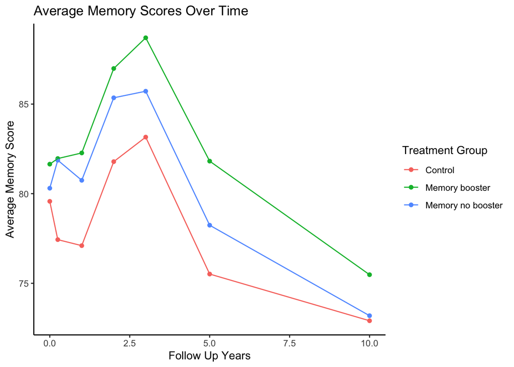

Figure 1

## Methods

We used generalized estimating equations (GEE) (Liang and Zeger 1986) in R with geeM (McDaniel et al. 2013) to account for correlation within participants, whose scores tend to be high or low together. We treated follow-up year as categorical because average scores did not change at a constant rate, giving each year its own mean but no single rate of change. We included baseline age as a linear term because the linear and LOESS fits at baseline were similar, except above about age 85.

We compared independence, exchangeable, and AR1 working correlation structures, which assume no correlation, equal correlation between any two scores, and weaker correlation for scores farther apart. We chose exchangeable, which implies the same correlation pattern as a participant random intercept, because scores stayed correlated even years apart, whereas AR1 correlation dropped too quickly and fit the uneven follow-up gaps poorly. Its model-based and robust standard errors were also closer at most time points than under the other structures. We used robust standard errors, which remain valid even if the correlation structure is not exactly right.

Our main model included an interaction between follow-up year and group (control, memory training not invited to boosters, and memory training invited to boosters). We compared each training group’s change from baseline with the control group’s in the short term (years 0.25–5) and long term (year 10). We also refitted the model with the no-booster group as the reference to compare the two training groups.

Residuals from our initial model showed a slight arch across predicted memory scores. We therefore added an interaction between follow-up year and baseline age, allowing the relationship between baseline age and memory scores to differ over time. After adding this interaction, the arch mostly disappeared and our conclusions about memory training did not change.

## Results

We analyzed 6,547 memory measurements from 1,391 participants. At baseline, 622 were in the control group, 329 in memory training with a booster invitation, and 291 without one. Scores from the same participant were strongly correlated (about 0.78). In all groups, average scores stayed similar or rose through year 3, then declined, ending well below baseline by year 10.

In the short term, both training groups had a more favorable change from baseline than the control group at every follow-up from years 0.25 to 5. For the booster-invited group, the difference was largest at year 5, when its average memory score declined 4.20 points less from baseline than the control group’s (95% CI 2.31 to 6.09, p < 0.001). By year 10, there was no evidence of a difference from the control group for either the booster-invited group (−0.10 points, 95% CI −2.86 to 2.66, p = 0.94) or the no-booster group.

We found no statistically significant difference between the two training groups at any follow-up. At year 5, the booster-invited group’s average memory score declined 1.13 points less from baseline than the no-booster group’s (95% CI −1.11 to 3.37, p = 0.32). At year 0.25, before booster sessions began, the two groups were also similar.

Older participants had lower baseline memory scores and showed greater declines over ten years. Participants who were 10 years older at baseline scored about 10 points lower on average at baseline, and this gap widened by about 8 points by year 10. Residuals from the final model were mostly centered around zero, with only a slight trend at the two extremes of the fitted values, where there were few observations (Figure 2).

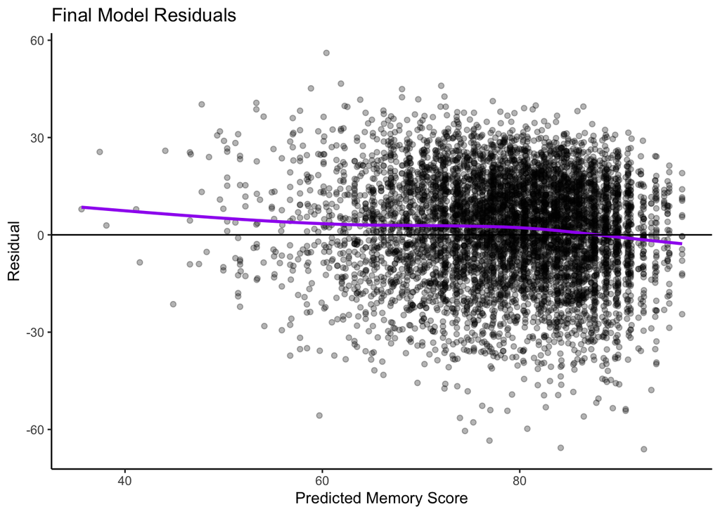

Figure 2: Residuals from the final model plotted against predicted memory scores.

## Conclusions

We found that both memory training groups had a more favorable change in memory scores than the control group within about five years. However, by year 10, we found no evidence that this advantage remained. We also found no evidence of a difference between the two memory training groups. Older participants declined faster over time.

Our results generally align with earlier findings. In our analysis of the ACTIVE data, the advantage of memory training was less clear by year 10, consistent with the trial’s published ten-year findings (Rebok et al. 2014). Like Borella et al. (2023), we found no clear booster benefit, although our analysis compared participants by booster invitation status rather than actual attendance. One possible explanation is that offering booster sessions at two time points may not be enough to maintain training benefits. The findings from Requena et al. (2016) suggest that training over a longer period may help maintain those benefits.

One limitation is that we only know whether participants were invited to booster training, not whether they attended, so we cannot conclude whether attending the booster sessions helped maintain memory scores. Another limitation is that many participants left the study by year 10, and those who remained may have been healthier, so our long-term results are less certain. Also, our residuals still showed a slight trend at the extremes, and few participants were older than 85, so our model may be less accurate for the oldest participants.

Overall, memory training may help older adults for several years, but maintaining those benefits may require longer or more frequent training than booster training at two time points, which future studies could test.

## Acknowledgements

We thank Professor Brianna Heggeseth for her guidance and feedback throughout this project. We also thank the ACTIVE study investigators and participants for making these data publicly available.

## References

Borella, Erika, Enrico Sella, Alessandro Simonetto, et al. 2023. “Effects of Strategy-Based Memory Training for Older Adults: Do Booster Sessions Prompt Long-Term Benefits?” *Brain Sciences* 13 (9): 1301. https://doi.org/10.3390/brainsci13091301.

Liang, Kung-Yee, and Scott L Zeger. 1986. “Longitudinal Data Analysis Using Generalized Linear Models.” *Biometrika* 73 (1): 13–22.

McDaniel, Lee S, Nicholas C Henderson, and Paul J Rathouz. 2013. “Fast Pure r Implementation of GEE: Application of the Matrix Package.” *The R Journal* 5 (1): 181–87.

Rebok, George W, Karlene Ball, Lin T Guey, et al. 2014. “Ten-Year Effects of the ACTIVE Cognitive Training Trial on Cognition and Everyday Functioning in Older Adults.” *Journal of the American Geriatrics Society* 62 (1): 16–24. https://doi.org/10.1111/jgs.12607.

Requena, Carmen, Agustín Turrero, and Tomás Ortiz. 2016. “Six-Year Training Improves Everyday Memory in Healthy Older People. Randomized Controlled Trial.” *Frontiers in Aging Neuroscience* 8: 135. https://doi.org/10.3389/fnagi.2016.00135.